# SPPH 504 Section 007 Lab (5.1) Propensity score Matching in CCHS

Ehsan Karim, ehsan.karim@ubc.ca

01 May 2020

# 1 OA - CVD problem from CCHS

This is the CCHS data, for the OA - CVD problem.

## 1.1 Load data

```r
load(file="data/cchs123c.RData")
head(analytic11n)
```

|  | CVD | age | sex | married | race | edu | income | bmi | phyact | doctor | stress | smoke | drink | fruit | bp | diab | province | weight | cycle | OA | immigrate |
| --- | --- | --- | --- | --- | --- | --- | --- | --- | --- | --- | --- | --- | --- | --- | --- | --- | --- | --- | --- | --- | --- |
| 17838 | no event | 30-39 years | Female | single | Non-white | Other 2nd grad. | $50,000-$79,999 | healthy weight | Inactive | Yes | Not too stressed | Current smoker | Current drinker | 0-3 daily serving | No | No | North | 20.66 | 11 | 0 | not immigrant |
| 17839 | no event | 30-39 years | Female | single | White | Post-2nd grad. | $50,000-$79,999 | healthy weight | Moderate | No | Not too stressed | Current smoker | Current drinker | 4-6 daily serving | No | No | North | 15.06 | 11 | 0 | not immigrant |
| 17842 | event | 50-59 years | Female | not single | Non-white | < 2ndary | $80,000 or more | healthy weight | Inactive | No | Not too stressed | Never smoker | Never drank | 6+ daily serving | Yes | No | North | 74.04 | 11 | 0 | not immigrant |
| 17844 | no event | 30-39 years | Female | not single | Non-white | Post-2nd grad. | $80,000 or more | healthy weight | Inactive | Yes | Not too stressed | Former smoker | Current drinker | 4-6 daily serving | No | No | North | 30.47 | 11 | 0 | not immigrant |
| 17846 | no event | 30-39 years | Male | single | White | Post-2nd grad. | $30,000-$49,999 | Overweight | Inactive | No | Not too stressed | Never smoker | Current drinker | 0-3 daily serving | No | No | North | 12.10 | 11 | 0 | not immigrant |
| 17847 | no event | 30-39 years | Male | single | White | Post-2nd grad. | $50,000-$79,999 | Overweight | Inactive | Yes | Not too stressed | Current smoker | Current drinker | 6+ daily serving | No | No | North | 16.90 | 11 | 0 | not immigrant |

```r
# later we will create another variable called weights
# hence to avoid any conflict/ambiguity,
# renaming weight variable to survey.weight
analytic11n$survey.weight <- analytic11n$weight
analytic11n$weight <- NULL
```

## 1.2 Analysis

We are going to apply propensity score analysis (Matching) in our OA - CVD problem from CCHS. For computation considerations, we will only work with cycle 1.1, and the people from Northern provinces in Canada (`analytic11n` data).

# 2 Step 1

## 2.1 Specify PS

```r
ps.formula <- as.formula("OA ~ age + sex + stress + married +
                         income + race + bmi + phyact + smoke +
                        doctor + drink + bp +
                         immigrate + fruit + diab + edu")
var.names <- c("age", "sex", "stress", "married",
               "income", "race", "bmi", "phyact", "smoke",
               "doctor", "drink", "bp",
               "immigrate", "fruit", "diab", "edu")
```

## 2.2 Fit model

The software fits the PS model using a logistic regression by default. This package actually performs stap 1 and 2 with one command `matchit`.

Look at the website for [arguments of matchit](https://www.rdocumentation.org/packages/MatchIt/versions/1.0-1/topics/matchit). It looks like this

```r
matchit(formula, data, model="logit", discard=0, reestimate=FALSE, nearest=TRUE,
                 replace=FALSE, m.order=2, ratio=1, caliper=0, calclosest=FALSE,
                 subclass=0, sub.by="treat", mahvars=NULL, exact=FALSE, counter=TRUE, full=FALSE, full.options=list(),...)
```

# 3 Step 2

## 3.1 Match subjects by PS

We are going to match using a Nearest neighbor algorithm. This is a greedy matching algorithm. Note that we are not even defining any caliper

```r
# set seed
set.seed(123)
# match
matching.obj <- matchit(ps.formula,
                        data = analytic11n,
                        method = "nearest",
                        ratio = 1)
# see how many matched
matching.obj
```

```
##
## Call:
## matchit(formula = ps.formula, data = analytic11n, method = "nearest",
##     ratio = 1)
##
## Sample sizes:
##           Control Treated
## All          1357      67
## Matched        67      67
## Unmatched    1290       0
## Discarded       0       0
```

```r
# create the "matched"" data
OACVD.match <- match.data(matching.obj)
# see the dimension
dim(analytic11n)
```

```
## [1] 1424   21
```

```r
dim(OACVD.match)
```

```
## [1] 134  23
```

Let’s try to understand how this is working.

### 3.1.1 Extract matched IDs

```r
m.mat<-matching.obj$match.matrix
head(m.mat)
```

```
##       1
## 17864 "96719"
## 17921 "17846"
## 18191 "97168"
## 18256 "111999"
## 18264 "17989"
## 18383 "108197"
```

### 3.1.2 Extract the matched treated IDs

```r
treated.id<-as.numeric(row.names(m.mat))
treated.id # basically row names
```

```
##  [1]  17864  17921  18191  18256  18264  18383  18389  18475  39105  96344
## [11]  96364  96407  96424  96460  96484  96571  96582  96625  96632  96641
## [21]  96657  96686  96693  96696  96705  96734  96795  96840  96913  97027
## [31]  97065  97125 108178 108183 108185 108192 111809 111813 111856 111859
## [41] 111895 111896 111920 111942 112014 112026 112046 112083 112086 112114
## [51] 112122 112151 112167 112189 112197 112215 112232 112245 112275 112284
## [61] 112289 112290 112300 112325 112375 126477 126522
```

### 3.1.3 Extract the matched untreated IDs

```r
untreated.id <- as.numeric(m.mat)
untreated.id # basically row names
```

```
##  [1]  96719  17846  97168 111999  17989 108197 112384  17909 126561 111880
## [11] 112184  18117  96865  18120  97023 112379  97017 126562  96356 126470
## [21] 126385  96374  18203  18262  96972 111924  96354  96983  18235  96882
## [31] 112054  18321  18426 112349  38996 126516 111814 112087  96569 111932
## [41] 126539  18315  96665  18225 112052 112324 112165  18329  96609 126376
## [51]  96474 126570 126547 126343  96680  96558 111931  96718  96533 111823
## [61] 112177  17953  17904 111908 111962  96644  96576
```

### 3.1.4 Extract the matched treated data

```r
tx <- analytic11n[rownames(analytic11n) %in% treated.id,]
head(tx[c("OA", "CVD", "sex", "age", "race", "edu")])
```

|  | OA | CVD | sex | age | race | edu |
| --- | --- | --- | --- | --- | --- | --- |
| 17864 | 1 | no event | Female | 40-49 years | Non-white | < 2ndary |
| 17921 | 1 | no event | Female | 30-39 years | White | Post-2nd grad. |
| 18191 | 1 | no event | Female | 40-49 years | Non-white | < 2ndary |
| 18256 | 1 | no event | Male | 30-39 years | Non-white | Post-2nd grad. |
| 18264 | 1 | no event | Male | 20-29 years | Non-white | < 2ndary |
| 18383 | 1 | no event | Male | 30-39 years | Non-white | < 2ndary |

### 3.1.5 Extract the matched untreated data

```r
utx <- analytic11n[rownames(analytic11n) %in% untreated.id,]
head(utx[c("OA", "CVD", "sex", "age", "race", "edu")])
```

|  | OA | CVD | sex | age | race | edu |
| --- | --- | --- | --- | --- | --- | --- |
| 17846 | 0 | no event | Male | 30-39 years | White | Post-2nd grad. |
| 17904 | 0 | no event | Female | 40-49 years | Non-white | < 2ndary |
| 17909 | 0 | no event | Female | 20-29 years | White | Post-2nd grad. |
| 17953 | 0 | no event | Male | 20-29 years | White | Post-2nd grad. |
| 17989 | 0 | event | Male | 30-39 years | Non-white | 2nd grad. |
| 18117 | 0 | no event | Female | 60-64 years | Non-white | < 2ndary |

### 3.1.6 Extract the matched data altogether

Simply using `match.data` is enough (as done earlier).

```r
OACVD.match <- match.data(matching.obj)
```

### 3.1.7 Assign match ID

```r
OACVD.match$match.ID <- NA
OACVD.match$match.ID[rownames(OACVD.match) %in% treated.id] <- 1:length(treated.id)
OACVD.match$match.ID[rownames(OACVD.match) %in% untreated.id] <- 1:length(untreated.id)
table(OACVD.match$match.ID)
```

```
##
##  1  2  3  4  5  6  7  8  9 10 11 12 13 14 15 16 17 18 19 20 21 22 23 24 25 26
##  2  2  2  2  2  2  2  2  2  2  2  2  2  2  2  2  2  2  2  2  2  2  2  2  2  2
## 27 28 29 30 31 32 33 34 35 36 37 38 39 40 41 42 43 44 45 46 47 48 49 50 51 52
##  2  2  2  2  2  2  2  2  2  2  2  2  2  2  2  2  2  2  2  2  2  2  2  2  2  2
## 53 54 55 56 57 58 59 60 61 62 63 64 65 66 67
##  2  2  2  2  2  2  2  2  2  2  2  2  2  2  2
```

Take a look at individual matches for the first match

```r
na.omit(OACVD.match[OACVD.match$match.ID == 1,])
```

|  | CVD | age | sex | married | race | edu | income | bmi | phyact | doctor | stress | smoke | drink | fruit | bp | diab | province | cycle | OA | immigrate | survey.weight | distance | weights | match.ID |
| --- | --- | --- | --- | --- | --- | --- | --- | --- | --- | --- | --- | --- | --- | --- | --- | --- | --- | --- | --- | --- | --- | --- | --- | --- |
| 17846 | no event | 30-39 years | Male | single | White | Post-2nd grad. | $30,000-$49,999 | Overweight | Inactive | No | Not too stressed | Never smoker | Current drinker | 0-3 daily serving | No | No | North | 11 | 0 | not immigrant | 12.10 | 0.01854076 | 1 | 1 |
| 17864 | no event | 40-49 years | Female | not single | Non-white | < 2ndary | $30,000-$49,999 | Overweight | Inactive | Yes | stressed | Current smoker | Current drinker | 4-6 daily serving | No | No | North | 11 | 1 | not immigrant | 38.23 | 0.18190027 | 1 | 1 |

Take a look at individual matches for the second match

```r
na.omit(OACVD.match[OACVD.match$match.ID == 2,])
```

|  | CVD | age | sex | married | race | edu | income | bmi | phyact | doctor | stress | smoke | drink | fruit | bp | diab | province | cycle | OA | immigrate | survey.weight | distance | weights | match.ID |
| --- | --- | --- | --- | --- | --- | --- | --- | --- | --- | --- | --- | --- | --- | --- | --- | --- | --- | --- | --- | --- | --- | --- | --- | --- |
| 17904 | no event | 40-49 years | Female | not single | Non-white | < 2ndary | $30,000-$49,999 | Overweight | Inactive | Yes | Not too stressed | Current smoker | Former driker | 0-3 daily serving | Yes | No | North | 11 | 0 | not immigrant | 52.04 | 0.06783228 | 1 | 2 |
| 17921 | no event | 30-39 years | Female | single | White | Post-2nd grad. | $29,999 or less | Overweight | Inactive | No | stressed | Never smoker | Current drinker | 0-3 daily serving | No | No | North | 11 | 1 | not immigrant | 15.88 | 0.01857417 | 1 | 2 |

# 4 Step 3

## 4.1 Examining PS graphically

### 4.1.1 matchit package

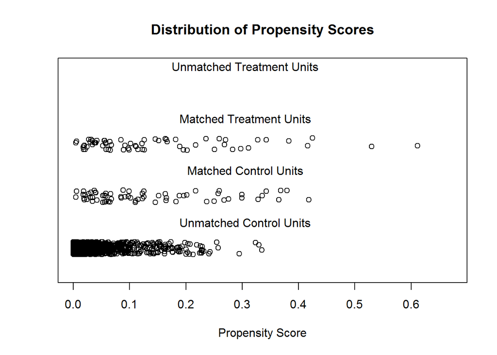

```
## [1] "To identify the units, use first mouse button; to stop, use second."
```

```
## integer(0)
```

```r
# plot(matching.obj) # covariate balance
plot(matching.obj, type = "jitter") # propensity score locations
```

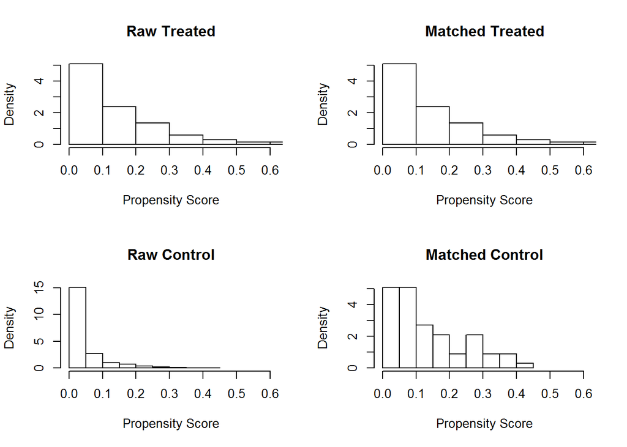

```r
plot(matching.obj, type = "hist") #check matched treated vs matched control
```

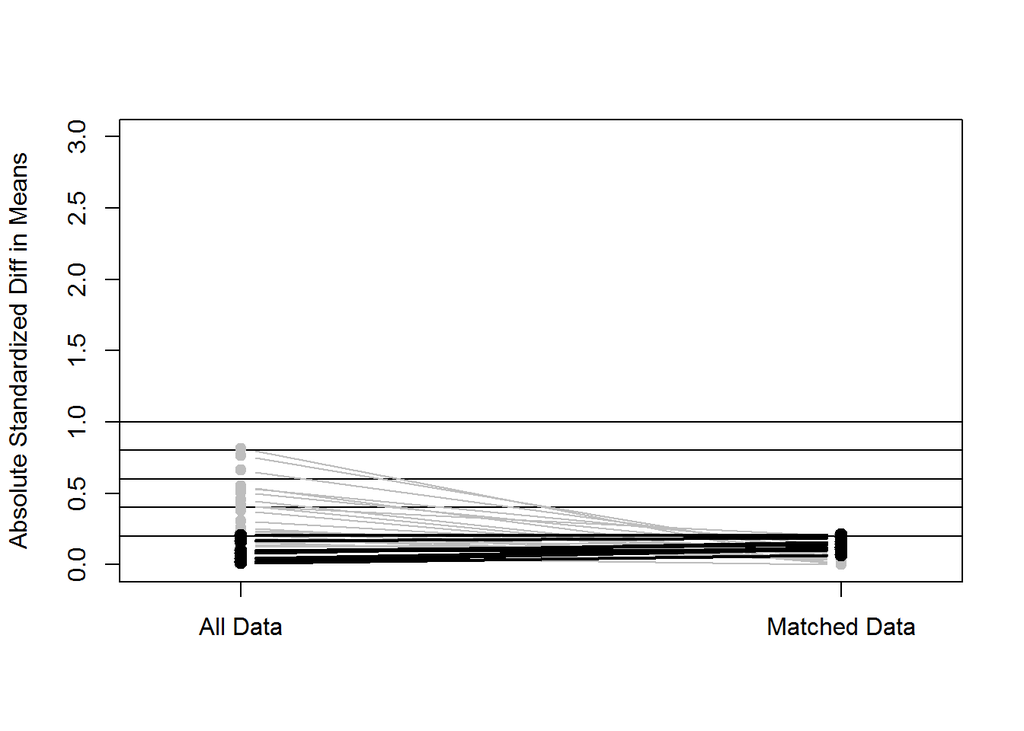

```
## [1] "To identify the variables, use first mouse button; to stop, use second."
```

```
## integer(0)
```

```r
summrize.output <- summary(matching.obj, standardize = TRUE)
plot(summrize.output)
```

### 4.1.2 Overalp check

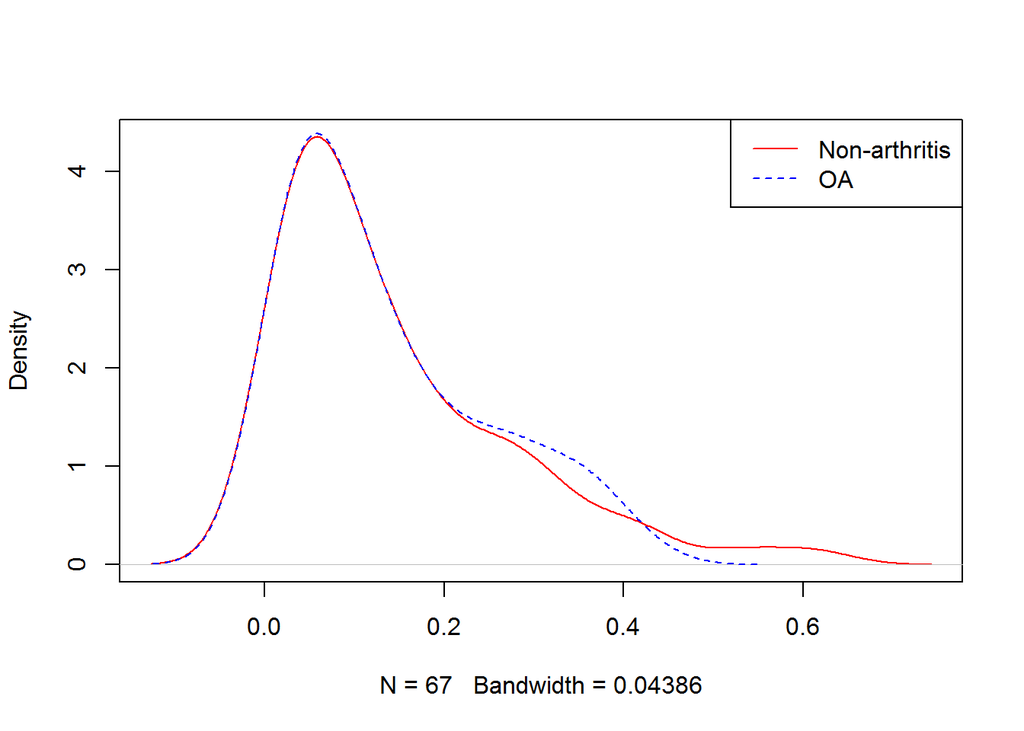

```r
# plot propensity scores by exposure group
plot(density(OACVD.match$distance[OACVD.match$OA==1]),
     col = "red", main = "")
lines(density(OACVD.match$distance[OACVD.match$OA==0]),
      col = "blue", lty = 2)
legend("topright", c("Non-arthritis","OA"),
       col = c("red", "blue"), lty=1:2)
```

### 4.1.3 cobalt package

Overlap check in a more convenient way

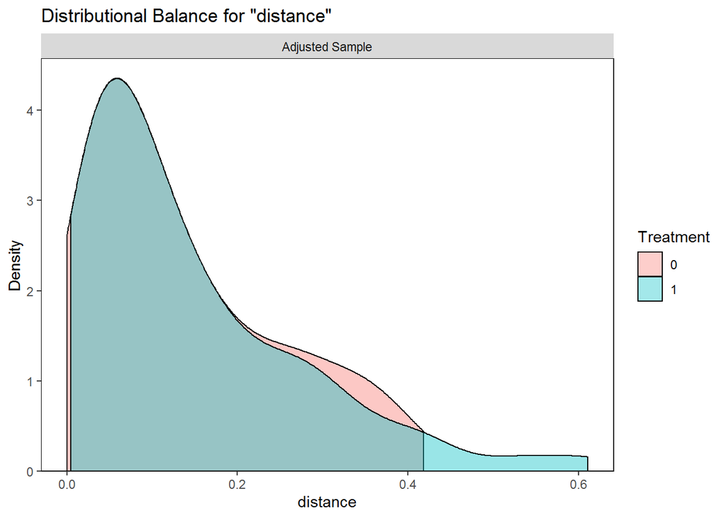

```r
# different badwidth
bal.plot(matching.obj, var.name = "distance")
```

### 4.1.4 Look at the data

```r
# what is distance variable here?
head(OACVD.match)
```

|  | CVD | age | sex | married | race | edu | income | bmi | phyact | doctor | stress | smoke | drink | fruit | bp | diab | province | cycle | OA | immigrate | survey.weight | distance | weights | match.ID |
| --- | --- | --- | --- | --- | --- | --- | --- | --- | --- | --- | --- | --- | --- | --- | --- | --- | --- | --- | --- | --- | --- | --- | --- | --- |
| 17846 | no event | 30-39 years | Male | single | White | Post-2nd grad. | $30,000-$49,999 | Overweight | Inactive | No | Not too stressed | Never smoker | Current drinker | 0-3 daily serving | No | No | North | 11 | 0 | not immigrant | 12.10 | 0.01854076 | 1 | 1 |
| 17864 | no event | 40-49 years | Female | not single | Non-white | < 2ndary | $30,000-$49,999 | Overweight | Inactive | Yes | stressed | Current smoker | Current drinker | 4-6 daily serving | No | No | North | 11 | 1 | not immigrant | 38.23 | 0.18190027 | 1 | 1 |
| 17904 | no event | 40-49 years | Female | not single | Non-white | < 2ndary | $30,000-$49,999 | Overweight | Inactive | Yes | Not too stressed | Current smoker | Former driker | 0-3 daily serving | Yes | No | North | 11 | 0 | not immigrant | 52.04 | 0.06783228 | 1 | 2 |
| 17909 | no event | 20-29 years | Female | not single | White | Post-2nd grad. | $80,000 or more | Overweight | Inactive | Yes | Not too stressed | Never smoker | Current drinker | 4-6 daily serving | No | No | North | 11 | 0 | not immigrant | 33.23 | 0.03126371 | 1 | 3 |
| 17921 | no event | 30-39 years | Female | single | White | Post-2nd grad. | $29,999 or less | Overweight | Inactive | No | stressed | Never smoker | Current drinker | 0-3 daily serving | No | No | North | 11 | 1 | not immigrant | 15.88 | 0.01857417 | 1 | 2 |
| 17953 | no event | 20-29 years | Male | not single | White | Post-2nd grad. | $50,000-$79,999 | Overweight | Moderate | No | Not too stressed | Never smoker | Current drinker | 0-3 daily serving | No | No | North | 11 | 0 | not immigrant | 26.91 | 0.00467081 | 1 | 4 |

### 4.1.5 Numerical values of PS

```r
summary(OACVD.match$distance)
```

```
##     Min.  1st Qu.   Median     Mean  3rd Qu.     Max.
## 0.004671 0.044834 0.099094 0.138969 0.200576 0.611166
```

```r
by(OACVD.match$distance, OACVD.match$OA, summary)
```

```
## OACVD.match$OA: 0
##     Min.  1st Qu.   Median     Mean  3rd Qu.     Max.
## 0.004671 0.047344 0.099215 0.135042 0.199279 0.418206
## ------------------------------------------------------------
## OACVD.match$OA: 1
##     Min.  1st Qu.   Median     Mean  3rd Qu.     Max.
## 0.004671 0.047346 0.098973 0.142897 0.198741 0.611166
```

### 4.1.6 Question for the students

- Are you happy with the matching after reviewing the plots?

## 4.2 Covariate balance in matched sample

```r
tab1 <- CreateTableOne(strata = "OA", data = OACVD.match,
                       test = FALSE, vars = var.names)
print(tab1, smd = TRUE)
```

```
##                        Stratified by OA
##                         0          1          SMD
##   n                     67         67
##   age (%)                                      0.190
##      20-29 years         4 ( 6.0)   4 ( 6.0)
##      30-39 years        16 (23.9)  11 (16.4)
##      40-49 years        16 (23.9)  18 (26.9)
##      50-59 years        28 (41.8)  31 (46.3)
##      60-64 years         3 ( 4.5)   3 ( 4.5)
##   sex = Male (%)        28 (41.8)  32 (47.8)   0.120
##   stress = stressed (%) 20 (29.9)  21 (31.3)   0.032
##   married = single (%)  22 (32.8)  23 (34.3)   0.032
##   income (%)                                   0.183
##      $29,999 or less    11 (16.4)  13 (19.4)
##      $30,000-$49,999    19 (28.4)  15 (22.4)
##      $50,000-$79,999    14 (20.9)  12 (17.9)
##      $80,000 or more    23 (34.3)  27 (40.3)
##   race = White (%)      43 (64.2)  44 (65.7)   0.031
##   bmi (%)                                     <0.001
##      Underweight         0 ( 0.0)   0 ( 0.0)
##      healthy weight     18 (26.9)  18 (26.9)
##      Overweight         49 (73.1)  49 (73.1)
##   phyact (%)                                   0.041
##      Active             16 (23.9)  16 (23.9)
##      Inactive           40 (59.7)  39 (58.2)
##      Moderate           11 (16.4)  12 (17.9)
##   smoke (%)                                    0.258
##      Never smoker       14 (20.9)   9 (13.4)
##      Current smoker     20 (29.9)  27 (40.3)
##      Former smoker      33 (49.3)  31 (46.3)
##   doctor = Yes (%)      51 (76.1)  47 (70.1)   0.135
##   drink (%)                                    0.116
##      Never drank         2 ( 3.0)   2 ( 3.0)
##      Current drinker    54 (80.6)  51 (76.1)
##      Former driker      11 (16.4)  14 (20.9)
##   bp = Yes (%)           7 (10.4)   5 ( 7.5)   0.105
##   immigrate (%)                                0.180
##      not immigrant      64 (95.5)  61 (91.0)
##      > 10 years          3 ( 4.5)   6 ( 9.0)
##      recent              0 ( 0.0)   0 ( 0.0)
##   fruit (%)                                    0.146
##      0-3 daily serving  19 (28.4)  19 (28.4)
##      4-6 daily serving  28 (41.8)  32 (47.8)
##      6+ daily serving   20 (29.9)  16 (23.9)
##   diab = Yes (%)         1 ( 1.5)   4 ( 6.0)   0.238
##   edu (%)                                      0.105
##      < 2ndary           14 (20.9)  13 (19.4)
##      2nd grad.           1 ( 1.5)   2 ( 3.0)
##      Other 2nd grad.     1 ( 1.5)   1 ( 1.5)
##      Post-2nd grad.     51 (76.1)  51 (76.1)
```

### 4.2.1 Question for the students

- All SMD < .20?

### 4.2.2 Other balance measures

#### 4.2.2.1 Individual categories

If you want to check balance at each category (not very useful in general situations). We are generally interested if the variables are balanced or not (not categories).

```r
baltab <- bal.tab(matching.obj)
baltab
```

```
## Call
##  matchit(formula = ps.formula, data = analytic11n, method = "nearest",
##     ratio = 1)
##
## Balance Measures
##                             Type Diff.Adj
## distance                Distance   0.0597
## age_20-29 years           Binary   0.0000
## age_30-39 years           Binary  -0.0746
## age_40-49 years           Binary   0.0299
## age_50-59 years           Binary   0.0448
## age_60-64 years           Binary   0.0000
## sex_Male                  Binary   0.0597
## stress_stressed           Binary   0.0149
## married_single            Binary   0.0149
## income_$29,999 or less    Binary   0.0299
## income_$30,000-$49,999    Binary  -0.0597
## income_$50,000-$79,999    Binary  -0.0299
## income_$80,000 or more    Binary   0.0597
## race_White                Binary   0.0149
## bmi_Underweight           Binary   0.0000
## bmi_healthy weight        Binary   0.0000
## bmi_Overweight            Binary   0.0000
## phyact_Active             Binary   0.0000
## phyact_Inactive           Binary  -0.0149
## phyact_Moderate           Binary   0.0149
## smoke_Never smoker        Binary  -0.0746
## smoke_Current smoker      Binary   0.1045
## smoke_Former smoker       Binary  -0.0299
## doctor_Yes                Binary  -0.0597
## drink_Never drank         Binary   0.0000
## drink_Current drinker     Binary  -0.0448
## drink_Former driker       Binary   0.0448
## bp_Yes                    Binary  -0.0299
## immigrate_not immigrant   Binary  -0.0448
## immigrate_> 10 years      Binary   0.0448
## immigrate_recent          Binary   0.0000
## fruit_0-3 daily serving   Binary   0.0000
## fruit_4-6 daily serving   Binary   0.0597
## fruit_6+ daily serving    Binary  -0.0597
## diab_Yes                  Binary   0.0448
## edu_< 2ndary              Binary  -0.0149
## edu_2nd grad.             Binary   0.0149
## edu_Other 2nd grad.       Binary   0.0000
## edu_Post-2nd grad.        Binary   0.0000
##
## Sample sizes
##           Control Treated
## All          1357      67
## Matched        67      67
## Unmatched    1290       0
```

#### 4.2.2.2 Individual plots

You could plot each variables individually

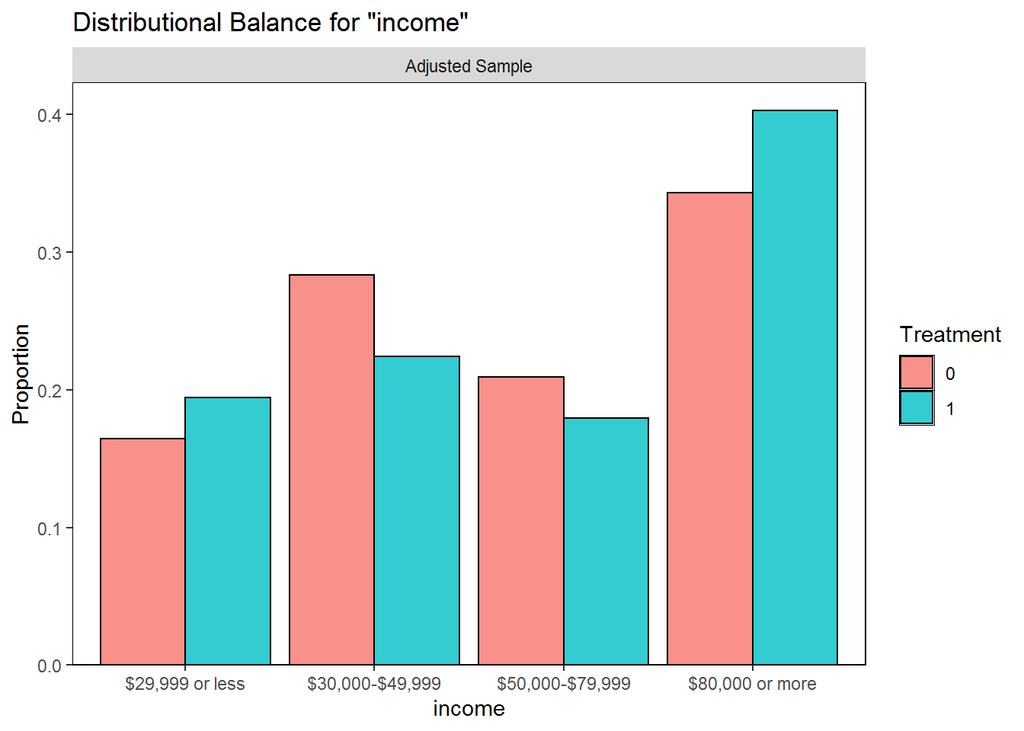

```r
bal.plot(matching.obj, var.name = "income")
```

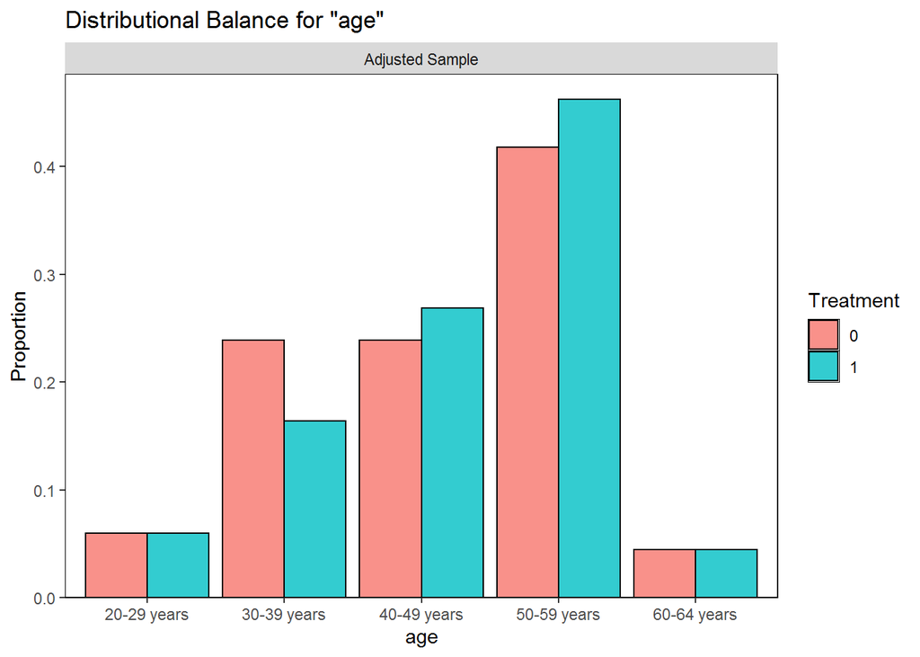

```r
bal.plot(matching.obj, var.name = "age")
```

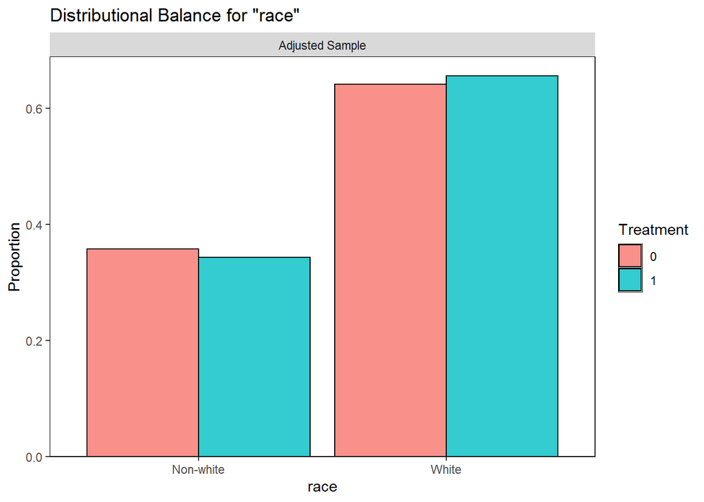

```r
bal.plot(matching.obj, var.name = "race")
```

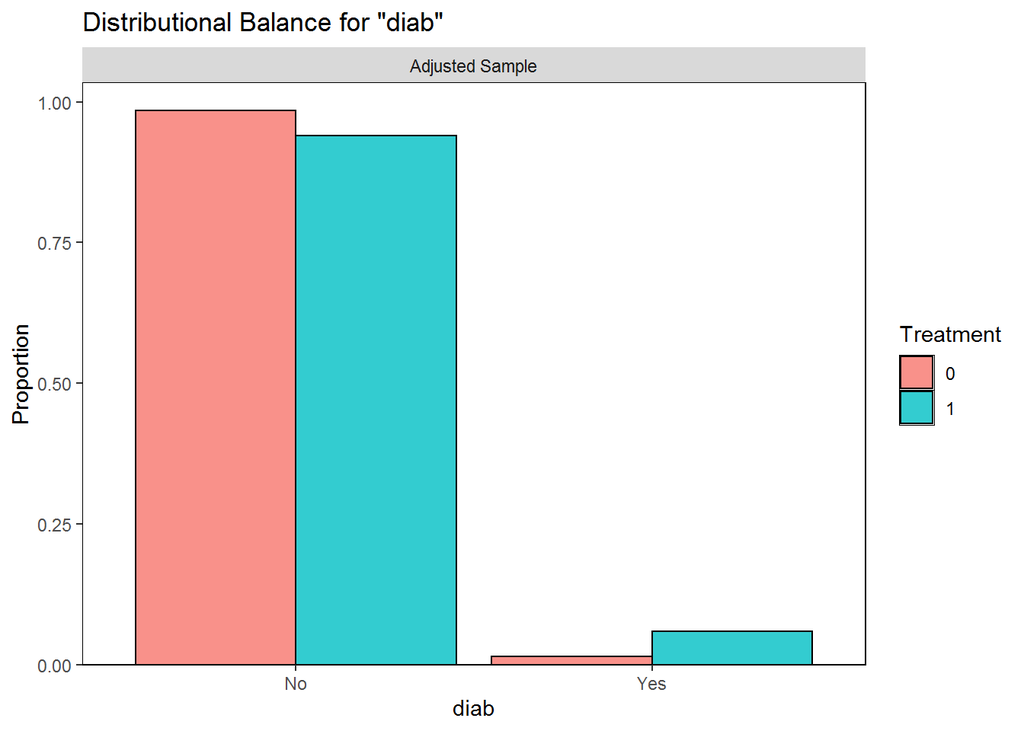

```r
bal.plot(matching.obj, var.name = "diab")
```

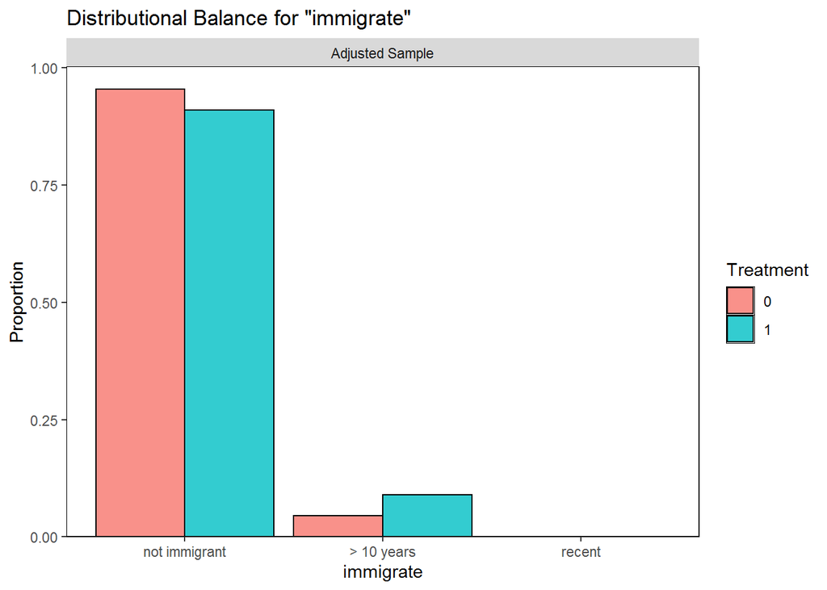

```r
bal.plot(matching.obj, var.name = "immigrate")
```

#### 4.2.2.3 Love plot

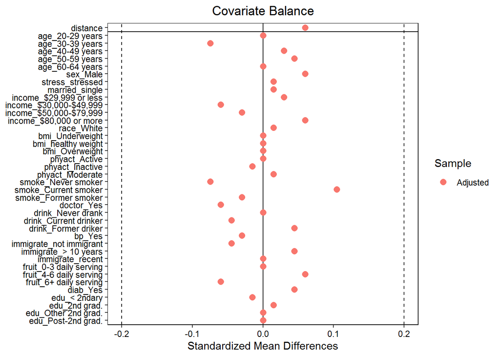

```r
# Individual categories again
love.plot(baltab, threshold = .2)
```

# 5 Repeat of Step 1-3 again

## 5.1 Add caliper

```r
# Step 1 and 2
matching.obj <- matchit(ps.formula,
                        data = analytic11n,
                        method = "nearest",
                        ratio = 1,
                        caliper = 0.2)
# see how many matched
matching.obj
```

```
##
## Call:
## matchit(formula = ps.formula, data = analytic11n, method = "nearest",
##     ratio = 1, caliper = 0.2)
##
## Sample sizes:
##           Control Treated
## All          1357      67
## Matched        64      64
## Unmatched    1293       3
## Discarded       0       0
```

```r
OACVD.match <- match.data(matching.obj)
# Step 3
by(OACVD.match$distance, OACVD.match$OA, summary)
```

```
## OACVD.match$OA: 0
##    Min. 1st Qu.  Median    Mean 3rd Qu.    Max.
## 0.00478 0.04204 0.08812 0.12328 0.17944 0.41821
## ------------------------------------------------------------
## OACVD.match$OA: 1
##     Min.  1st Qu.   Median     Mean  3rd Qu.     Max.
## 0.004671 0.041694 0.095089 0.125262 0.183739 0.424895
```

```r
tab1 <- CreateTableOne(strata = "OA", data = OACVD.match,
                       test = FALSE, vars = var.names)
print(tab1, smd = TRUE)
```

```
##                        Stratified by OA
##                         0          1          SMD
##   n                     64         64
##   age (%)                                      0.253
##      20-29 years         6 ( 9.4)   4 ( 6.2)
##      30-39 years         6 ( 9.4)  11 (17.2)
##      40-49 years        18 (28.1)  18 (28.1)
##      50-59 years        31 (48.4)  28 (43.8)
##      60-64 years         3 ( 4.7)   3 ( 4.7)
##   sex = Male (%)        28 (43.8)  30 (46.9)   0.063
##   stress = stressed (%) 16 (25.0)  18 (28.1)   0.071
##   married = single (%)  20 (31.2)  23 (35.9)   0.099
##   income (%)                                   0.172
##      $29,999 or less     9 (14.1)  13 (20.3)
##      $30,000-$49,999    14 (21.9)  14 (21.9)
##      $50,000-$79,999    13 (20.3)  12 (18.8)
##      $80,000 or more    28 (43.8)  25 (39.1)
##   race = White (%)      42 (65.6)  42 (65.6)  <0.001
##   bmi (%)                                      0.035
##      Underweight         0 ( 0.0)   0 ( 0.0)
##      healthy weight     17 (26.6)  18 (28.1)
##      Overweight         47 (73.4)  46 (71.9)
##   phyact (%)                                   0.096
##      Active             14 (21.9)  16 (25.0)
##      Inactive           39 (60.9)  36 (56.2)
##      Moderate           11 (17.2)  12 (18.8)
##   smoke (%)                                    0.095
##      Never smoker       10 (15.6)   9 (14.1)
##      Current smoker     28 (43.8)  26 (40.6)
##      Former smoker      26 (40.6)  29 (45.3)
##   doctor = Yes (%)      48 (75.0)  44 (68.8)   0.139
##   drink (%)                                    0.136
##      Never drank         1 ( 1.6)   2 ( 3.1)
##      Current drinker    52 (81.2)  49 (76.6)
##      Former driker      11 (17.2)  13 (20.3)
##   bp = Yes (%)          10 (15.6)   5 ( 7.8)   0.245
##   immigrate (%)                                0.056
##      not immigrant      59 (92.2)  58 (90.6)
##      > 10 years          5 ( 7.8)   6 ( 9.4)
##      recent              0 ( 0.0)   0 ( 0.0)
##   fruit (%)                                    0.122
##      0-3 daily serving  19 (29.7)  19 (29.7)
##      4-6 daily serving  33 (51.6)  30 (46.9)
##      6+ daily serving   12 (18.8)  15 (23.4)
##   diab = Yes (%)         4 ( 6.2)   3 ( 4.7)   0.069
##   edu (%)                                      0.233
##      < 2ndary           16 (25.0)  13 (20.3)
##      2nd grad.           4 ( 6.2)   2 ( 3.1)
##      Other 2nd grad.     2 ( 3.1)   1 ( 1.6)
##      Post-2nd grad.     42 (65.6)  48 (75.0)
```

### 5.1.1 Question for the students

- Did all of the SMDs decrease?

### 5.1.2 Look at the data

```r
# what is weights variable for pair matching?
head(OACVD.match)
```

|  | CVD | age | sex | married | race | edu | income | bmi | phyact | doctor | stress | smoke | drink | fruit | bp | diab | province | cycle | OA | immigrate | survey.weight | distance | weights |
| --- | --- | --- | --- | --- | --- | --- | --- | --- | --- | --- | --- | --- | --- | --- | --- | --- | --- | --- | --- | --- | --- | --- | --- |
| 17852 | no event | 40-49 years | Male | single | White | Post-2nd grad. | $50,000-$79,999 | Overweight | Moderate | Yes | Not too stressed | Former smoker | Current drinker | 4-6 daily serving | No | No | North | 11 | 0 | not immigrant | 12.52 | 0.05208657 | 1 |
| 17864 | no event | 40-49 years | Female | not single | Non-white | < 2ndary | $30,000-$49,999 | Overweight | Inactive | Yes | stressed | Current smoker | Current drinker | 4-6 daily serving | No | No | North | 11 | 1 | not immigrant | 38.23 | 0.18190027 | 1 |
| 17869 | no event | 50-59 years | Female | not single | Non-white | Post-2nd grad. | $80,000 or more | Overweight | Inactive | Yes | Not too stressed | Never smoker | Current drinker | 6+ daily serving | Yes | No | North | 11 | 0 | not immigrant | 25.49 | 0.17308582 | 1 |
| 17904 | no event | 40-49 years | Female | not single | Non-white | < 2ndary | $30,000-$49,999 | Overweight | Inactive | Yes | Not too stressed | Current smoker | Former driker | 0-3 daily serving | Yes | No | North | 11 | 0 | not immigrant | 52.04 | 0.06783228 | 1 |
| 17912 | no event | 50-59 years | Male | single | White | Post-2nd grad. | $80,000 or more | healthy weight | Moderate | No | stressed | Current smoker | Current drinker | 4-6 daily serving | No | No | North | 11 | 0 | not immigrant | 16.67 | 0.05348864 | 1 |
| 17921 | no event | 30-39 years | Female | single | White | Post-2nd grad. | $29,999 or less | Overweight | Inactive | No | stressed | Never smoker | Current drinker | 0-3 daily serving | No | No | North | 11 | 1 | not immigrant | 15.88 | 0.01857417 | 1 |

```r
summary(OACVD.match$weights)
```

```
##    Min. 1st Qu.  Median    Mean 3rd Qu.    Max.
##       1       1       1       1       1       1
```

# 6 Step 4

## 6.1 Estimate treatment effect

### 6.1.1 Unconditional logistic

```r
outcome.model <- glm(CVD ~ OA, data = OACVD.match, family = binomial())
publish(outcome.model)
```

```
##  Variable Units OddsRatio       CI.95  p-value
##        OA            0.48 [0.09;2.74]   0.4119
```

### 6.1.2 Survey design

```r
w.design <- svydesign(ids = ~1, data = OACVD.match, weight = ~survey.weight)
fit.design <- svyglm(I(CVD=="event") ~ OA, design = w.design,
       family = binomial(logit))
publish(fit.design)
```

```
##  Variable Units OddsRatio        CI.95  p-value
##        OA            2.79 [0.45;17.32]   0.2738
```

# 7 Advanced options

## 7.1 Increase ratio

```r
# Step 1 and 2
matching.obj <- matchit(ps.formula,
                        data = analytic11n,
                        method = "nearest",
                        ratio = 5,
                        caliper = 0.2)
# see how many matched
matching.obj
```

```
##
## Call:
## matchit(formula = ps.formula, data = analytic11n, method = "nearest",
##     ratio = 5, caliper = 0.2)
##
## Sample sizes:
##           Control Treated
## All          1357      67
## Matched       285      64
## Unmatched    1072       3
## Discarded       0       0
```

```r
OACVD.match <- match.data(matching.obj)
# Step 3
by(OACVD.match$distance, OACVD.match$OA, summary)
```

```
## OACVD.match$OA: 0
##    Min. 1st Qu.  Median    Mean 3rd Qu.    Max.
## 0.00000 0.03714 0.07889 0.10008 0.14591 0.41821
## ------------------------------------------------------------
## OACVD.match$OA: 1
##     Min.  1st Qu.   Median     Mean  3rd Qu.     Max.
## 0.004671 0.041694 0.095089 0.125262 0.183739 0.424895
```

```r
tab1 <- CreateTableOne(strata = "OA", data = OACVD.match,
                       test = FALSE, vars = var.names)
print(tab1, smd = TRUE)
```

```
##                        Stratified by OA
##                         0           1          SMD
##   n                     285         64
##   age (%)                                       0.205
##      20-29 years         26 ( 9.1)   4 ( 6.2)
##      30-39 years         56 (19.6)  11 (17.2)
##      40-49 years         91 (31.9)  18 (28.1)
##      50-59 years         98 (34.4)  28 (43.8)
##      60-64 years         14 ( 4.9)   3 ( 4.7)
##   sex = Male (%)        135 (47.4)  30 (46.9)   0.010
##   stress = stressed (%)  82 (28.8)  18 (28.1)   0.014
##   married = single (%)  105 (36.8)  23 (35.9)   0.019
##   income (%)                                    0.106
##      $29,999 or less     67 (23.5)  13 (20.3)
##      $30,000-$49,999     68 (23.9)  14 (21.9)
##      $50,000-$79,999     48 (16.8)  12 (18.8)
##      $80,000 or more    102 (35.8)  25 (39.1)
##   race = White (%)      166 (58.2)  42 (65.6)   0.152
##   bmi (%)                                       0.153
##      Underweight          2 ( 0.7)   0 ( 0.0)
##      healthy weight      92 (32.3)  18 (28.1)
##      Overweight         191 (67.0)  46 (71.9)
##   phyact (%)                                    0.044
##      Active              76 (26.7)  16 (25.0)
##      Inactive           159 (55.8)  36 (56.2)
##      Moderate            50 (17.5)  12 (18.8)
##   smoke (%)                                     0.112
##      Never smoker        41 (14.4)   9 (14.1)
##      Current smoker     130 (45.6)  26 (40.6)
##      Former smoker      114 (40.0)  29 (45.3)
##   doctor = Yes (%)      184 (64.6)  44 (68.8)   0.089
##   drink (%)                                     0.030
##      Never drank         10 ( 3.5)   2 ( 3.1)
##      Current drinker    215 (75.4)  49 (76.6)
##      Former driker       60 (21.1)  13 (20.3)
##   bp = Yes (%)           19 ( 6.7)   5 ( 7.8)   0.044
##   immigrate (%)                                 0.046
##      not immigrant      262 (91.9)  58 (90.6)
##      > 10 years          23 ( 8.1)   6 ( 9.4)
##      recent               0 ( 0.0)   0 ( 0.0)
##   fruit (%)                                     0.055
##      0-3 daily serving   90 (31.6)  19 (29.7)
##      4-6 daily serving  134 (47.0)  30 (46.9)
##      6+ daily serving    61 (21.4)  15 (23.4)
##   diab = Yes (%)         11 ( 3.9)   3 ( 4.7)   0.041
##   edu (%)                                       0.066
##      < 2ndary            63 (22.1)  13 (20.3)
##      2nd grad.           11 ( 3.9)   2 ( 3.1)
##      Other 2nd grad.      5 ( 1.8)   1 ( 1.6)
##      Post-2nd grad.     206 (72.3)  48 (75.0)
```

### 7.1.1 Question for the students

- Did all of the SMDs decrease?

### 7.1.2 Look at the data

```r
# what is weights variable now for 1:5 ratio?
head(OACVD.match)
```

|  | CVD | age | sex | married | race | edu | income | bmi | phyact | doctor | stress | smoke | drink | fruit | bp | diab | province | cycle | OA | immigrate | survey.weight | distance | weights |
| --- | --- | --- | --- | --- | --- | --- | --- | --- | --- | --- | --- | --- | --- | --- | --- | --- | --- | --- | --- | --- | --- | --- | --- |
| 17863 | no event | 50-59 years | Female | not single | Non-white | < 2ndary | $29,999 or less | Overweight | Inactive | No | Not too stressed | Current smoker | Never drank | 0-3 daily serving | No | No | North | 11 | 0 | not immigrant | 34.98 | 0.09000168 | 0.890625 |
| 17864 | no event | 40-49 years | Female | not single | Non-white | < 2ndary | $30,000-$49,999 | Overweight | Inactive | Yes | stressed | Current smoker | Current drinker | 4-6 daily serving | No | No | North | 11 | 1 | not immigrant | 38.23 | 0.18190027 | 1.000000 |
| 17869 | no event | 50-59 years | Female | not single | Non-white | Post-2nd grad. | $80,000 or more | Overweight | Inactive | Yes | Not too stressed | Never smoker | Current drinker | 6+ daily serving | Yes | No | North | 11 | 0 | not immigrant | 25.49 | 0.17308582 | 0.890625 |
| 17873 | no event | 30-39 years | Male | not single | White | Post-2nd grad. | $80,000 or more | Overweight | Active | No | Not too stressed | Former smoker | Current drinker | 6+ daily serving | No | No | North | 11 | 0 | not immigrant | 33.81 | 0.04331415 | 0.890625 |
| 17882 | no event | 50-59 years | Male | single | White | Post-2nd grad. | $80,000 or more | Overweight | Inactive | No | Not too stressed | Current smoker | Former driker | 0-3 daily serving | No | No | North | 11 | 0 | not immigrant | 19.52 | 0.10536495 | 0.890625 |
| 17901 | no event | 20-29 years | Male | not single | Non-white | < 2ndary | $29,999 or less | healthy weight | Active | Yes | Not too stressed | Current smoker | Current drinker | 4-6 daily serving | No | No | North | 11 | 0 | not immigrant | 31.45 | 0.01428043 | 0.890625 |

```r
summary(OACVD.match$weights)
```

```
##    Min. 1st Qu.  Median    Mean 3rd Qu.    Max.
##  0.8906  0.8906  0.8906  1.0000  0.8906  4.4531
```

### 7.1.3 Step 4: Unconditional/weighted logistic

```r
outcome.model <- glm(CVD ~ OA, data = OACVD.match,
                     family = binomial(),
                     weight = weights)
publish(outcome.model)
```

```
##  Variable Units OddsRatio       CI.95  p-value
##        OA            0.71 [0.22;2.26]   0.5645
```

### 7.1.4 Survey design

```r
# multiply with matching (ratio) weights with survey weights
OACVD.match$combined.weight <- OACVD.match$weights*OACVD.match$survey.weight
w.design <- svydesign(ids = ~1, data = OACVD.match, weight = ~combined.weight)
fit.design <- svyglm(I(CVD=="event") ~ OA, design = w.design,
       family = binomial(logit))
publish(fit.design)
```

```
##  Variable Units OddsRatio       CI.95  p-value
##        OA            1.54 [0.37;6.37]   0.5504
```

## 7.2 with replacement

```r
# Step 1 and 2
matching.obj <- matchit(ps.formula,
                        data = analytic11n,
                        method = "nearest",
                        ratio = 5,
                        caliper = 0.2,
                        replace = TRUE)
# see how many matched
matching.obj
```

```
##
## Call:
## matchit(formula = ps.formula, data = analytic11n, method = "nearest",
##     ratio = 5, caliper = 0.2, replace = TRUE)
##
## Sample sizes:
##           Control Treated
## All          1357      67
## Matched       240      65
## Unmatched    1117       2
## Discarded       0       0
```

```r
OACVD.match <- match.data(matching.obj)
# Step 3
by(OACVD.match$distance, OACVD.match$OA, summary)
```

```
## OACVD.match$OA: 0
##    Min. 1st Qu.  Median    Mean 3rd Qu.    Max.
## 0.00000 0.03404 0.06930 0.09895 0.14454 0.41821
## ------------------------------------------------------------
## OACVD.match$OA: 1
##     Min.  1st Qu.   Median     Mean  3rd Qu.     Max.
## 0.004671 0.042322 0.097877 0.129743 0.189255 0.424895
```

```r
tab1 <- CreateTableOne(strata = "OA", data = OACVD.match,
                       test = FALSE, vars = var.names)
print(tab1, smd = TRUE)
```

```
##                        Stratified by OA
##                         0           1          SMD
##   n                     240         65
##   age (%)                                       0.181
##      20-29 years         18 ( 7.5)   4 ( 6.2)
##      30-39 years         48 (20.0)  11 (16.9)
##      40-49 years         75 (31.2)  18 (27.7)
##      50-59 years         86 (35.8)  29 (44.6)
##      60-64 years         13 ( 5.4)   3 ( 4.6)
##   sex = Male (%)        118 (49.2)  31 (47.7)   0.030
##   stress = stressed (%)  57 (23.8)  19 (29.2)   0.124
##   married = single (%)   92 (38.3)  23 (35.4)   0.061
##   income (%)                                    0.089
##      $29,999 or less     56 (23.3)  13 (20.0)
##      $30,000-$49,999     53 (22.1)  14 (21.5)
##      $50,000-$79,999     41 (17.1)  12 (18.5)
##      $80,000 or more     90 (37.5)  26 (40.0)
##   race = White (%)      148 (61.7)  42 (64.6)   0.061
##   bmi (%)                                       0.189
##      Underweight          2 ( 0.8)   0 ( 0.0)
##      healthy weight      81 (33.8)  18 (27.7)
##      Overweight         157 (65.4)  47 (72.3)
##   phyact (%)                                    0.127
##      Active              62 (25.8)  16 (24.6)
##      Inactive           123 (51.2)  37 (56.9)
##      Moderate            55 (22.9)  12 (18.5)
##   smoke (%)                                     0.003
##      Never smoker        33 (13.8)   9 (13.8)
##      Current smoker      96 (40.0)  26 (40.0)
##      Former smoker      111 (46.2)  30 (46.2)
##   doctor = Yes (%)      156 (65.0)  45 (69.2)   0.090
##   drink (%)                                     0.102
##      Never drank          5 ( 2.1)   2 ( 3.1)
##      Current drinker    194 (80.8)  50 (76.9)
##      Former driker       41 (17.1)  13 (20.0)
##   bp = Yes (%)           19 ( 7.9)   5 ( 7.7)   0.008
##   immigrate (%)                                 0.017
##      not immigrant      219 (91.2)  59 (90.8)
##      > 10 years          21 ( 8.8)   6 ( 9.2)
##      recent               0 ( 0.0)   0 ( 0.0)
##   fruit (%)                                     0.089
##      0-3 daily serving   79 (32.9)  19 (29.2)
##      4-6 daily serving  112 (46.7)  31 (47.7)
##      6+ daily serving    49 (20.4)  15 (23.1)
##   diab = Yes (%)          9 ( 3.8)   3 ( 4.6)   0.043
##   edu (%)                                       0.098
##      < 2ndary            55 (22.9)  13 (20.0)
##      2nd grad.           10 ( 4.2)   2 ( 3.1)
##      Other 2nd grad.      4 ( 1.7)   1 ( 1.5)
##      Post-2nd grad.     171 (71.2)  49 (75.4)
```

### 7.2.1 Question for the students

- Did all of the SMDs decrease?

### 7.2.2 Look at the data

```r
# what is weights variable now for 1:5 ratio?
head(OACVD.match)
```

|  | CVD | age | sex | married | race | edu | income | bmi | phyact | doctor | stress | smoke | drink | fruit | bp | diab | province | cycle | OA | immigrate | survey.weight | distance | weights |
| --- | --- | --- | --- | --- | --- | --- | --- | --- | --- | --- | --- | --- | --- | --- | --- | --- | --- | --- | --- | --- | --- | --- | --- |
| 17852 | no event | 40-49 years | Male | single | White | Post-2nd grad. | $50,000-$79,999 | Overweight | Moderate | Yes | Not too stressed | Former smoker | Current drinker | 4-6 daily serving | No | No | North | 11 | 0 | not immigrant | 12.52 | 5.208657e-02 | 0.7384615 |
| 17856 | no event | 40-49 years | Female | single | White | Post-2nd grad. | $30,000-$49,999 | healthy weight | Inactive | No | Not too stressed | Current smoker | Current drinker | 4-6 daily serving | No | No | North | 11 | 0 | not immigrant | 43.67 | 4.082613e-02 | 0.7384615 |
| 17864 | no event | 40-49 years | Female | not single | Non-white | < 2ndary | $30,000-$49,999 | Overweight | Inactive | Yes | stressed | Current smoker | Current drinker | 4-6 daily serving | No | No | North | 11 | 1 | not immigrant | 38.23 | 1.819003e-01 | 1.0000000 |
| 17872 | no event | 20-29 years | Female | single | White | Post-2nd grad. | $50,000-$79,999 | Overweight | Active | No | Not too stressed | Former smoker | Current drinker | 4-6 daily serving | No | No | North | 11 | 0 | not immigrant | 13.94 | 1.120192e-02 | 0.7384615 |
| 17886 | event | 30-39 years | Female | not single | Non-white | < 2ndary | $29,999 or less | Underweight | Moderate | No | Not too stressed | Current smoker | Never drank | 0-3 daily serving | No | No | North | 11 | 0 | not immigrant | 39.32 | 5.659030e-09 | 0.7384615 |
| 17906 | no event | 40-49 years | Female | not single | White | Post-2nd grad. | $80,000 or more | Overweight | Inactive | No | Not too stressed | Never smoker | Former driker | 4-6 daily serving | Yes | Yes | North | 11 | 0 | not immigrant | 31.77 | 3.433141e-02 | 0.7384615 |

```r
summary(OACVD.match$weights)
```

```
##    Min. 1st Qu.  Median    Mean 3rd Qu.    Max.
##  0.7385  0.7385  0.7385  1.0000  1.0000  7.3846
```

```r
# Step 4: Unconditional/weighted logistic
outcome.model <- glm(CVD ~ OA, data = OACVD.match,
                     family = binomial(),
                     weight = weights)
publish(outcome.model)
```

```
##  Variable Units OddsRatio       CI.95  p-value
##        OA            0.87 [0.27;2.76]   0.8102
```

### 7.2.3 Survey design

```r
# multiply with matching (ratio+replacement) weights with survey weights
OACVD.match$combined.weight <- OACVD.match$weights*OACVD.match$survey.weight
w.design <- svydesign(ids = ~1, data = OACVD.match, weight = ~combined.weight)
fit.design <- svyglm(I(CVD=="event") ~ OA, design = w.design,
       family = binomial(logit))
publish(fit.design)
```

```
##  Variable Units OddsRatio       CI.95  p-value
##        OA            1.10 [0.29;4.20]   0.8938
```